# LSTAT2110 - Analyse des données : TP3

Antoine Soetewey, Johan Segers et Baptiste Feraud

2018-2019

# 1 Déroulement des TPs

- TP1 :
  - Introduction à R
  - Statistiques descriptives
  - Manipulation de matrices
  - Analyse en Composantes Principales (ACP)
- TP2 :
  - Classification (*clustering* en anglais)
  - Analyse discriminante
- TP3 (pas LSTAT2110A) :
  - Analyse des correspondances simples
  - Discrétiser une variable continue
  - Analyse des correspondances multiples

# 2 Relations entre variables

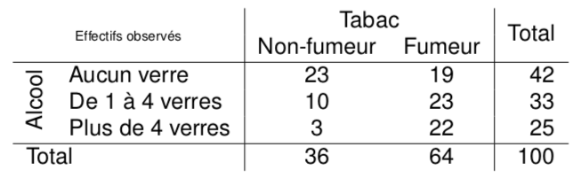

Quelles relations entre ces 2 variables ? Il existe plusieurs outils statistiques :

- Test d’indépendance (*chi-carré*)
- Force de l’association ($\phi$, *V* de Cramer)
- Analyse factorielle des correspondances

## 2.1 Test d’indépendance

Le test d’indépendance entre deux variables revient à mesurer l’écart entre ce qu’on observe et ce que l’on s’attend à observer dans une situation théorique d’indépendance.

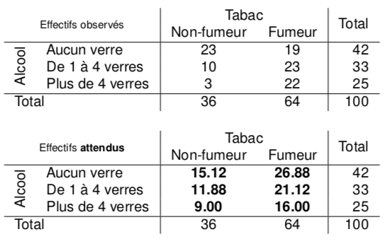

Les hypothèses sont les suivantes :
$$H_0 : P(i,j) = P(i) \times P(j) \text{ (les variables sont indépendantes)}$$
$$H_1 : P(i,j) \neq P(i) \times P(j) \text{ (les variables sont dépendantes)}$$

En R :

```r
# Create the data frame
data <- data.frame(
   Non_fumeur = c(23,10,3),
   Fumeur = c(19,23,22),
   row.names = c("Aucun verre", "De 1 à 4 verres", "Plus de 4 verres"),
   stringsAsFactors = FALSE
)
# Print the data frame
print(data)
```

```
                 Non_fumeur Fumeur
Aucun verre              23     19
De 1 à 4 verres          10     23
Plus de 4 verres          3     22
```

```r
# Chi-squared test
test <- chisq.test(data, correct = FALSE)
test
```

```
    Pearson's Chi-squared test

data:  data
X-squared = 13.132, df = 2, p-value = 0.001408
```

```r
# Affichage des effectifs espérés :
round(test$expected, 2)
```

```
                 Non_fumeur Fumeur
Aucun verre           15.12  26.88
De 1 à 4 verres       11.88  21.12
Plus de 4 verres       9.00  16.00
```

```r
# Affichage des résidus :
round(test$residuals, 2)
```

```
                 Non_fumeur Fumeur
Aucun verre            2.03  -1.52
De 1 à 4 verres       -0.55   0.41
Plus de 4 verres      -2.00   1.50
```

Si l’hypothèse d’indépendance est rejetée (par exemple : *p*-valeur < 0.05) comme c’est le cas dans notre exemple, les variables ne sont pas indépendantes et il est alors intéressant d’observer la contribution de chacune des modalités par rapport à ce rejet.

$\rightarrow$ Analyse factorielle des correspondances simples (AFCS)

# 3 AFCS sur une base de données

On peut appliquer l’analyse des correspondances simples directement sur une base de donnée (à la place d’un tableau croisé) si :

- Lorsque l’on additionne toutes les valeurs d’une ligne, on peut tirer du résultat une interprétation pertinente (également avec les autres opérations mathématiques telle la moyenne)
- Lorsque l’on additionne toutes les valeurs d’une colonne, on peut tirer du résultat une interprétation pertinente (également avec les autres opérations mathématiques telle la moyenne)

## 3.1 Eurojobs

```r
Eurojobs <- read.csv(file="Eurojobs.csv", sep=",", dec=".", header=TRUE) # importation des données
rownames(Eurojobs) <- Eurojobs$Country #définition des noms des pays comme identifiants des lignes
Eurojobs$Country <- NULL #retrait de la variable pays

head(Eurojobs)
```

```
            Agr Min  Man  PS  Con   SI Fin  SPS  TC
Belgium     3.3 0.9 27.6 0.9  8.2 19.1 6.2 26.6 7.2
Denmark     9.2 0.1 21.8 0.6  8.3 14.6 6.5 32.2 7.1
France     10.8 0.8 27.5 0.9  8.9 16.8 6.0 22.6 5.7
W. Germany  6.7 1.3 35.8 0.9  7.3 14.4 5.0 22.3 6.1
Ireland    23.2 1.0 20.7 1.3  7.5 16.8 2.8 20.8 6.1
Italy      15.9 0.6 27.6 0.5 10.0 18.1 1.6 20.1 5.7
```

```r
round(rowSums(Eurojobs), digits = 2)
```

```
       Belgium        Denmark         France     W. Germany        Ireland
         100.0          100.4          100.0           99.8          100.2
         Italy     Luxembourg    Netherlands United Kingdom        Austria
         100.1          100.1           99.9           99.9           99.9
       Finland         Greece         Norway       Portugal          Spain
         100.1           99.9           99.9          100.0           99.9
        Sweden    Switzerland         Turkey       Bulgaria Czechoslovakia
         100.0           99.9           99.7           99.9           99.8
    E. Germany        Hungary         Poland        Rumania           USSR
         100.1          100.0          100.0          100.1          100.2
    Yugoslavia
         100.0
```

```r
round(colMeans(Eurojobs), digits = 2)
```

```
  Agr   Min   Man    PS   Con    SI   Fin   SPS    TC
19.13  1.25 27.01  0.91  8.17 12.96  4.00 20.02  6.55
```

## 3.2 `CA()`

```r
library("FactoMineR")
EurojobsCA <- CA(Eurojobs, ncp = 5, graph = FALSE)
EurojobsCA
```

```
**Results of the Correspondence Analysis (CA)**
The row variable has  26  categories; the column variable has 9 categories
The chi square of independence between the two variables is equal to 547.9056 (p-value =  3.776432e-34 ).
*The results are available in the following objects:

   name              description
1  "$eig"            "eigenvalues"
2  "$col"            "results for the columns"
3  "$col$coord"      "coord. for the columns"
4  "$col$cos2"       "cos2 for the columns"
5  "$col$contrib"    "contributions of the columns"
6  "$row"            "results for the rows"
7  "$row$coord"      "coord. for the rows"
8  "$row$cos2"       "cos2 for the rows"
9  "$row$contrib"    "contributions of the rows"
10 "$call"           "summary called parameters"
11 "$call$marge.col" "weights of the columns"
12 "$call$marge.row" "weights of the rows"
```

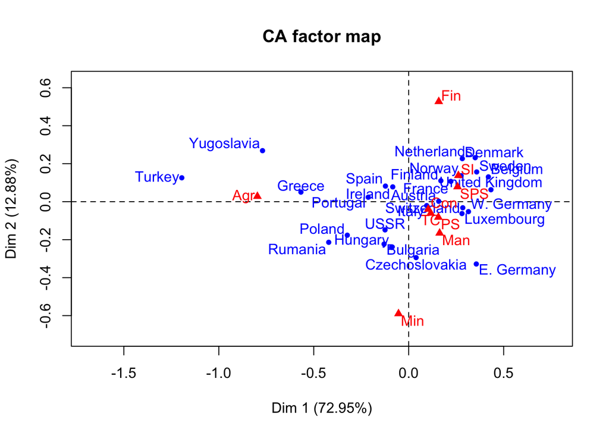

```r
plot(EurojobsCA)
```

### 3.2.1 Valeurs propres

```r
round(EurojobsCA$eig, digits = 2)
```

```
      eigenvalue percentage of variance cumulative percentage of variance
dim 1       0.15                  72.95                             72.95
dim 2       0.03                  12.88                             85.83
dim 3       0.02                   7.42                             93.25
dim 4       0.01                   3.17                             96.42
dim 5       0.00                   1.69                             98.11
dim 6       0.00                   1.12                             99.23
dim 7       0.00                   0.55                             99.78
dim 8       0.00                   0.22                            100.00
```

### 3.2.2 Sorties clés pour les colonnes

```r
lapply(EurojobsCA$col, round, 2)
```

```
$coord
    Dim 1 Dim 2 Dim 3 Dim 4 Dim 5
Agr -0.80  0.03 -0.02 -0.01  0.00
Min -0.05 -0.59  0.13  0.20  0.38
Man  0.16 -0.17  0.09  0.00 -0.03
PS   0.16 -0.08  0.10  0.08  0.21
Con  0.10 -0.04  0.04 -0.06 -0.08
SI   0.26  0.14  0.00 -0.17  0.07
Fin  0.16  0.53  0.38  0.17  0.01
SPS  0.26  0.08 -0.18  0.07  0.00
TC   0.12 -0.06 -0.08  0.04 -0.01

$contrib
    Dim 1 Dim 2 Dim 3 Dim 4 Dim 5
Agr 79.01  0.55  0.54  0.13  0.01
Min  0.02 16.06  1.43  7.79 49.71
Man  4.66 27.21 14.43  0.02  6.86
PS   0.14  0.22  0.55  0.93 11.22
Con  0.56  0.48  0.94  3.98 15.34
SI   5.77  9.07  0.00 53.58 16.66
Fin  0.65 40.96 36.21 17.07  0.03
SPS  8.60  4.55 43.25 14.61  0.02
TC   0.57  0.89  2.65  1.89  0.15

$cos2
    Dim 1 Dim 2 Dim 3 Dim 4 Dim 5
Agr  1.00  0.00  0.00  0.00  0.00
Min  0.01  0.60  0.03  0.07  0.25
Man  0.41  0.42  0.13  0.00  0.01
PS   0.15  0.04  0.06  0.04  0.27
Con  0.27  0.04  0.05  0.08  0.17
SI   0.57  0.16  0.00  0.23  0.04
Fin  0.05  0.59  0.30  0.06  0.00
SPS  0.59  0.06  0.30  0.04  0.00
TC   0.31  0.08  0.15  0.04  0.00

$inertia
[1] 0.12 0.01 0.02 0.00 0.00 0.02 0.02 0.02 0.00
```

### 3.2.3 Sorties clés pour les lignes

```r
lapply(EurojobsCA$row, round, 2)
```

```
$coord
               Dim 1 Dim 2 Dim 3 Dim 4 Dim 5
Belgium         0.42  0.13 -0.01 -0.02  0.04
Denmark         0.28  0.23 -0.14  0.10 -0.05
France          0.22  0.11  0.04 -0.03  0.00
W. Germany      0.31 -0.05  0.08  0.03 -0.02
Ireland        -0.08  0.08 -0.10 -0.10  0.08
Italy           0.09 -0.02 -0.06 -0.19 -0.03
Luxembourg      0.28 -0.06  0.10 -0.06  0.14
Netherlands     0.35  0.23 -0.06  0.00 -0.02
United Kingdom  0.43  0.06 -0.02  0.06  0.07
Austria         0.16  0.00  0.11 -0.08  0.02
Finland         0.17  0.11 -0.03  0.03 -0.01
Greece         -0.57  0.05 -0.03 -0.12 -0.01
Norway          0.28  0.14 -0.13  0.00  0.00
Portugal       -0.21  0.02 -0.03 -0.10 -0.05
Spain          -0.12  0.08  0.27  0.04 -0.12
Sweden          0.36  0.16 -0.12  0.11 -0.03
Switzerland     0.28 -0.03  0.20 -0.13 -0.09
Turkey         -1.19  0.13 -0.20 -0.02  0.03
Bulgaria       -0.13 -0.22 -0.04  0.03 -0.05
Czechoslovakia  0.04 -0.29  0.02  0.04  0.02
E. Germany      0.36 -0.33  0.02  0.07  0.02
Hungary        -0.09 -0.24 -0.02  0.05  0.09
Poland         -0.32 -0.18 -0.05  0.03  0.02
Rumania        -0.42 -0.21  0.05  0.01 -0.05
USSR           -0.12 -0.15 -0.19  0.10 -0.09
Yugoslavia     -0.77  0.27  0.32  0.15  0.07

$contrib
               Dim 1 Dim 2 Dim 3 Dim 4 Dim 5
Belgium         4.41  2.42  0.01  0.14  1.65
Denmark         2.00  7.32  4.99  5.66  2.22
France          1.23  1.62  0.46  0.48  0.01
W. Germany      2.47  0.39  1.67  0.46  0.25
Ireland         0.18  0.86  2.40  5.92  7.34
Italy           0.22  0.06  0.93 20.40  0.77
Luxembourg      1.97  0.55  2.58  2.13 21.48
Netherlands     3.06  7.59  0.84  0.00  0.31
United Kingdom  4.69  0.56  0.07  1.87  5.00
```

[output cut: 35 more lines]

```
Sweden          0.69  0.13  0.08  0.07  0.00
Switzerland     0.52  0.01  0.27  0.12  0.05
Turkey          0.96  0.01  0.03  0.00  0.00
Bulgaria        0.23  0.68  0.02  0.01  0.04
Czechoslovakia  0.02  0.95  0.01  0.02  0.00
E. Germany      0.52  0.44  0.00  0.02  0.00
Hungary         0.10  0.68  0.00  0.03  0.10
Poland          0.73  0.22  0.02  0.01  0.00
Rumania         0.77  0.20  0.01  0.00  0.01
USSR            0.16  0.22  0.37  0.10  0.09
Yugoslavia      0.75  0.09  0.13  0.03  0.01

$inertia
 [1] 0.01 0.01 0.00 0.00 0.00 0.00 0.00 0.01 0.01 0.00 0.00 0.01 0.00 0.00
[15] 0.00 0.01 0.01 0.06 0.00 0.00 0.01 0.00 0.01 0.01 0.00 0.03
```

### 3.2.4 Représentation - regarder `$cos2`

Quel est la modalité et l’individu avec la meilleure (pire) représentation dans le premier plan factoriel (dimension 1 et 2) ?

```r
round(sort(rowSums(EurojobsCA$col$cos2[,1:2])), digits = 3)
```

```
   PS   Con    TC   Min   Fin   SPS    SI   Man   Agr
0.189 0.313 0.397 0.609 0.640 0.647 0.730 0.832 0.999
```

```r
round(sort(rowSums(EurojobsCA$row$cos2[,1:2])), digits = 3)
```

```
         Spain          Italy        Ireland           USSR        Austria
         0.184          0.185          0.316          0.382          0.519
   Switzerland     Luxembourg       Portugal        Hungary         Norway
         0.530          0.650          0.755          0.777          0.784
       Denmark         Sweden     Yugoslavia     W. Germany        Finland
         0.799          0.828          0.837          0.864          0.868
      Bulgaria         Greece United Kingdom         France         Poland
         0.908          0.939          0.941          0.942          0.950
   Netherlands     E. Germany        Rumania         Turkey Czechoslovakia
         0.960          0.962          0.963          0.966          0.968
       Belgium
         0.987
```

`Agr` (`PS`) est la colonne la mieux (moins bien) représentée sur le premier plan factoriel. `Belgium` (`Spain`) est la ligne la mieux (moins bien) représentée sur le premier plan factoriel.

### 3.2.5 Interprétation des axes - regarder `$contrib`

Pour interpréter un certain axe, il faut regarder les contributions (en %) dans chacune des composantes principales :

```r
round(EurojobsCA$col$contrib[,c(1,2)], digits = 3)
```

```
     Dim 1  Dim 2
Agr 79.012  0.551
Min  0.024 16.064
Man  4.662 27.207
PS   0.144  0.225
Con  0.564  0.481
SI   5.766  9.073
Fin  0.652 40.961
SPS  8.602  4.553
TC   0.575  0.885
```

Les colonnes qui contribuent le plus à Dim.1 et à Dim.2 sont les plus importantes pour expliquer la variabilité de l’ensemble de données. Les colonnes qui ne contribuent pas beaucoup à une dimension ou qui contribuent aux dernières dimensions sont moins importantes.

# 4 AFCS vs ACP

En travaillant avec l’AFCS :

- On change de standardisation (de centré-réduit à une division par la racine du profil moyen)
- On change de métrique (d’Euclidienne à Chi-carré)
- **On obtient une représentation simultanée des variables et des individus**

## 4.1 Comparaison des valeurs propres entre ACP et AFCS

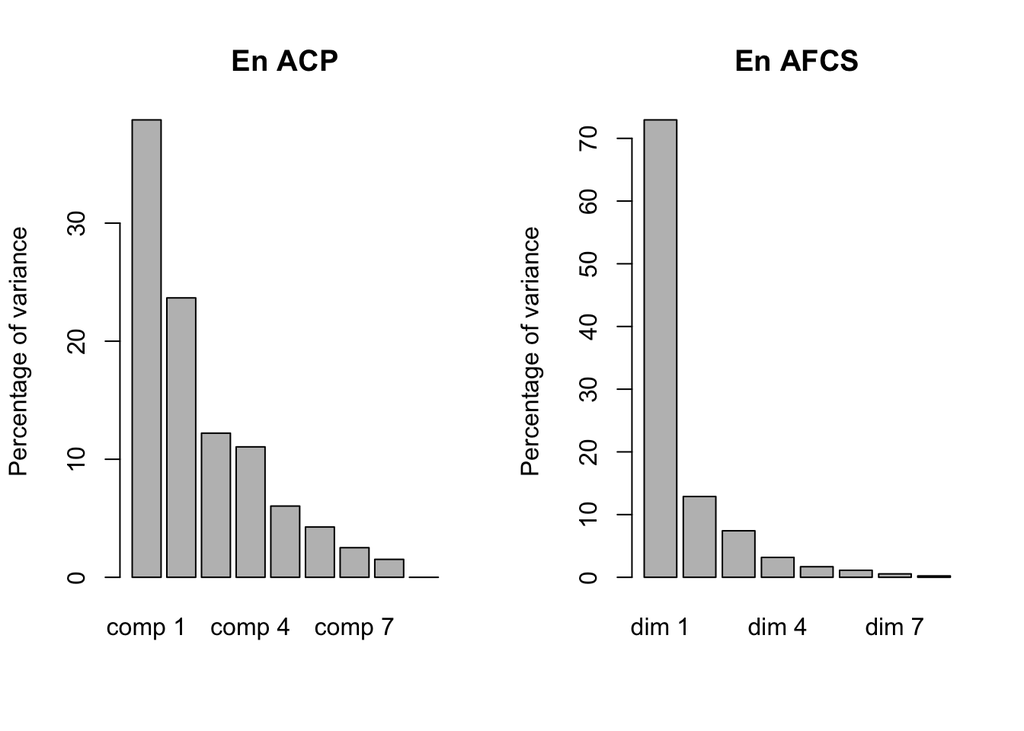

```r
par(mfrow=c(1,2))

EurojobsPCA <- PCA(Eurojobs, graph=FALSE)
barplot(EurojobsPCA$eig[,"percentage of variance"], ylab = "Percentage of variance", main = "En ACP")
barplot(EurojobsCA$eig[,"percentage of variance"], ylab = "Percentage of variance", main = "En AFCS")
```

# 5 Discrétiser une variable continue

Il existe plusieurs façons de discrétiser une variable continue :

- Classes de taille égale (fonction de l’étendue)
- Classes basées sur les quantiles (effectifs égaux)
- Classes ‘naturelles’ (algorithme k-means - cf. Clustering)
- Avec la fonction `cut()` :
  - Classes de taille égale (fonction de l’étendue)
  - Classes prédéfinies (ex : classes d’âge)

$\rightarrow$ Possibilité d’effectuer ensuite des statistiques descriptives sur ces nouvelles classes !

En R :

```r
load("Ronfle.rda") # détails de cette base de données plus bas

Ronfle$AgeDiscr <- cut(Ronfle$Age, breaks = c(min(Ronfle$Age), 40, 50, 60, 70, max(Ronfle$Age)), labels=c("<40", "40-49", "50-59", "60-69", ">=70"), include.lowest = TRUE, right = FALSE)

summary(Ronfle$AgeDiscr)
```

```
  <40 40-49 50-59 60-69  >=70
   15    30    24    27     4
```

# 6 Analyse des Correspondances Multiples (ACM)

## 6.1 Objectif de l’Analyse des Correspondances Multiples

En ACM, l’objectif est d’obtenir une représentation graphique où …

- toutes les modalités des variables initiales et les individus sont représentés sur un même plan
- la proximité (l’éloignement) d’une modalité et d’un individu prend un sens intrinsèque
- le centre du plan ou de l’axe (l’origine) a également du sens intrinsèque

## 6.2 La base de données `Ronfle.rda`

- Données concernant 100 individus
- A propos desquels les variables suivantes sont disponibles : Âge (+ version discrétisée), Poids, Taille, IMC (+ version discrétisée), Alcool (+ version discrétisée), Sexe, Ronfle, Tabac
- Format de données .rda (rdata) : pour l’importation, passer par `load("Ronfle.rda")`

### 6.2.1 ACM en R - fonction `MCA()`

```r
Ronfle.MCA <- Ronfle[, c("Sexe", "Ronfle", "Tabac", "AlcoolDisc", "AgeDisc", "IMCDisc")]
res.MCA <- MCA(Ronfle.MCA, ncp=5, graph = FALSE)
res.MCA
```

```
**Results of the Multiple Correspondence Analysis (MCA)**
The analysis was performed on 100 individuals, described by 6 variables
*The results are available in the following objects:

   name              description
1  "$eig"            "eigenvalues"
2  "$var"            "results for the variables"
3  "$var$coord"      "coord. of the categories"
4  "$var$cos2"       "cos2 for the categories"
5  "$var$contrib"    "contributions of the categories"
6  "$var$v.test"     "v-test for the categories"
7  "$ind"            "results for the individuals"
8  "$ind$coord"      "coord. for the individuals"
9  "$ind$cos2"       "cos2 for the individuals"
10 "$ind$contrib"    "contributions of the individuals"
11 "$call"           "intermediate results"
12 "$call$marge.col" "weights of columns"
13 "$call$marge.li"  "weights of rows"
```

### 6.2.2 Les valeurs propres

```r
round(res.MCA$eig, digits = 3)
```

```
       eigenvalue percentage of variance cumulative percentage of variance
dim 1       0.328                 16.403                            16.403
dim 2       0.233                 11.639                            28.042
dim 3       0.226                 11.281                            39.323
dim 4       0.198                  9.900                            49.223
dim 5       0.183                  9.139                            58.362
dim 6       0.155                  7.765                            66.127
dim 7       0.152                  7.624                            73.751
dim 8       0.139                  6.937                            80.688
dim 9       0.131                  6.527                            87.215
dim 10      0.113                  5.673                            92.888
dim 11      0.083                  4.136                            97.024
dim 12      0.060                  2.976                           100.000
```

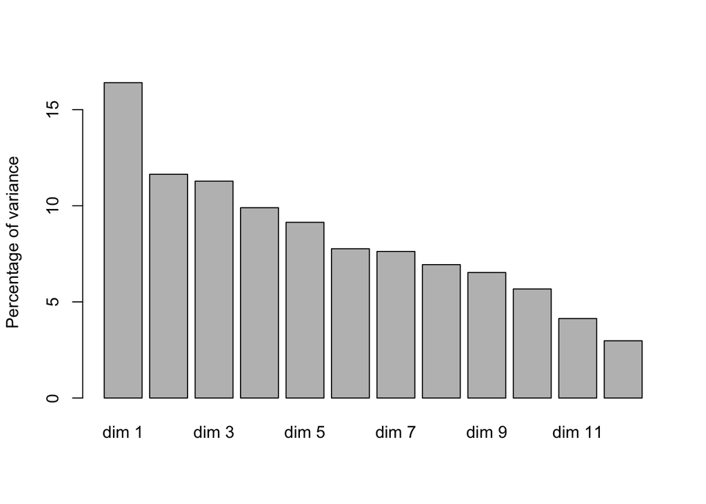

```r
barplot(res.MCA$eig[,"percentage of variance"], ylab = "Percentage of variance")
```

### 6.2.3 Les résultats pour les variables

```r
lapply(res.MCA$var, round, 3)
```

```
$coord
                    Dim 1  Dim 2  Dim 3  Dim 4  Dim 5
Homme               0.463  0.025 -0.042  0.030  0.041
Femme              -1.389 -0.075  0.126 -0.091 -0.123
Ne ronfle pas      -0.278 -0.456 -0.063  0.084  0.055
Ronfle              0.516  0.846  0.116 -0.155 -0.103
Non-fumeur         -0.728  0.736  0.043 -0.279 -0.044
Fumeur              0.410 -0.414 -0.024  0.157  0.025
Aucun verre        -0.999  0.004  0.008  0.049  0.059
De 1 \xe0 4 verres  0.582  0.048  0.753 -0.361  0.139
Plus de 4 verres    0.910 -0.071 -1.008  0.395 -0.282
<40                -0.100 -1.447 -0.130 -0.285  0.787
40-49              -0.320  0.061 -0.928  0.134 -0.301
50-59               0.501 -0.104  0.374 -0.672 -0.849
60-69              -0.164  0.522  0.850  0.846  0.274
>=70                0.880  2.069 -0.536 -1.611  2.555
Insuffisance        0.388 -1.900  2.421 -0.589  2.031
Normal              0.224  0.188  0.767  1.721 -0.553
Surpoids           -0.064 -0.028 -0.088 -0.420 -0.208
Ob\xe8se            0.040  0.509 -1.157  0.831  1.685

$contrib
                    Dim 1  Dim 2  Dim 3  Dim 4  Dim 5
Homme               8.169  0.033  0.097  0.059  0.115
Femme              24.507  0.100  0.292  0.176  0.346
Ne ronfle pas       2.551  9.666  0.189  0.383  0.182
Ronfle              4.737 17.951  0.350  0.710  0.338
Non-fumeur          9.696 13.963  0.050  2.360  0.063
Fumeur              5.454  7.854  0.028  1.328  0.036
Aucun verre        21.296  0.000  0.002  0.085  0.132
De 1 \xe0 4 verres  5.683  0.055 13.832  3.626  0.580
Plus de 4 verres   10.515  0.089 18.767  3.276  1.811
<40                 0.077 22.494  0.187  1.026  8.469
40-49               1.565  0.081 19.086  0.451  2.484
50-59               3.061  0.187  2.485  9.121 15.793
60-69               0.368  5.273 14.407 16.263  1.852
>=70                1.573 12.256  0.848  8.741 23.815
Insuffisance        0.230  7.751 12.990  0.877 11.287
Normal              0.357  0.353  6.082 34.893  3.904
Surpoids            0.154  0.040  0.418 10.818  2.888
```

[output cut: 37 more lines]

```
60-69              -0.991  3.160  5.143  5.119  1.660
>=70                1.787  4.202 -1.088 -3.272  5.190
Insuffisance        0.679 -3.324  4.236 -1.031  3.554
Normal              0.900  0.754  3.079  6.908 -2.220
Surpoids           -1.054 -0.452 -1.441 -6.865 -3.408
Ob\xe8se            0.133  1.687 -3.838  2.755  5.590

$eta2
           Dim 1 Dim 2 Dim 3 Dim 4 Dim 5
Sexe       0.643 0.002 0.005 0.003 0.005
Ronfle     0.143 0.386 0.007 0.013 0.006
Tabac      0.298 0.305 0.001 0.044 0.001
AlcoolDisc 0.738 0.002 0.441 0.083 0.028
AgeDisc    0.131 0.563 0.501 0.423 0.575
IMCDisc    0.015 0.140 0.398 0.622 0.482
```

### 6.2.4 Résultats graphiques

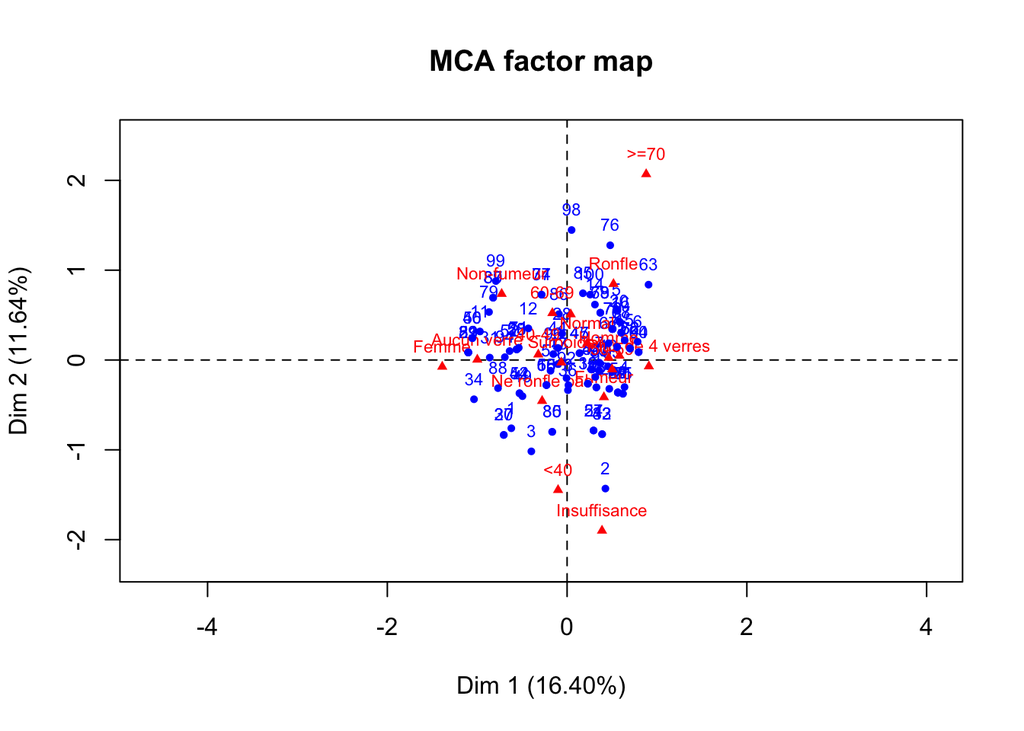

```r
plot(res.MCA, cex = 0.7)
```

### 6.2.5 Représentation - regarder `$cos2`

Quel est la modalité et l’individu avec la meilleure (pire) représentation dans le premier plan factoriel (dimension 1 et 2) ?

```r
round(sort(rowSums(res.MCA$var$cos2[,1:2])), digits = 3)
```

```
          Surpoids             Normal           Ob\xe8se
             0.013              0.014              0.029
             40-49              50-59              60-69
             0.046              0.083              0.111
      Insuffisance De 1 \xe0 4 verres               >=70
             0.116              0.168              0.211
  Plus de 4 verres                <40      Ne ronfle pas
             0.278              0.371              0.529
            Ronfle             Fumeur         Non-fumeur
             0.529              0.603              0.603
             Femme              Homme        Aucun verre
             0.645              0.645              0.723
```

```r
round(sort(rowSums(res.MCA$ind$cos2[,1:2])), digits = 3)
```

```
   13    17    96    92    45    47    44     8    53    91    93    97
0.006 0.006 0.012 0.013 0.018 0.018 0.023 0.031 0.049 0.054 0.054 0.054
    7     9    28     4    41    48    51    10    95    36    20    19
0.064 0.068 0.069 0.075 0.080 0.080 0.080 0.096 0.103 0.107 0.112 0.119
   38    18    55    60    12    33    46    94     3    86    14    15
0.119 0.142 0.142 0.142 0.144 0.167 0.167 0.168 0.175 0.182 0.185 0.193
   71   100    67     5    16    65    81    49    52    69    78    61
0.194 0.195 0.199 0.226 0.231 0.235 0.235 0.244 0.250 0.260 0.260 0.268
   75    25    42    54     6    70    73    23    50    58    63    68
0.268 0.277 0.278 0.278 0.280 0.288 0.288 0.293 0.293 0.293 0.304 0.310
   77     2    98     1    26    29    82    84    62    66    72    76
0.310 0.323 0.328 0.334 0.339 0.339 0.339 0.339 0.366 0.366 0.366 0.368
   85    11    64    90    99    37    74    31    24    57    35    80
0.385 0.402 0.414 0.414 0.426 0.434 0.434 0.435 0.444 0.444 0.452 0.452
   32    43    88    79    34    27    30    87    89    40    56    21
0.478 0.478 0.505 0.582 0.595 0.621 0.621 0.626 0.626 0.719 0.719 0.776
   22    39    59    83
0.776 0.776 0.776 0.776
```

`Aucun verre` (`Surpoids`) est la variable la mieux (moins bien) représentée sur le premier plan factoriel. L’individu `83` (`13`) est l’individu le mieux (moins bien) représenté sur le premier plan factoriel.

### 6.2.6 Interprétation des axes - regarder `$contrib`

Pour interpréter un certain axe, il faut regarder les contributions (en %) dans chacune des composantes principales :

```r
round(res.MCA$var$contrib[,c(1,2)], digits = 3)
```

```
                    Dim 1  Dim 2
Homme               8.169  0.033
Femme              24.507  0.100
Ne ronfle pas       2.551  9.666
Ronfle              4.737 17.951
Non-fumeur          9.696 13.963
Fumeur              5.454  7.854
Aucun verre        21.296  0.000
De 1 \xe0 4 verres  5.683  0.055
Plus de 4 verres   10.515  0.089
<40                 0.077 22.494
40-49               1.565  0.081
50-59               3.061  0.187
60-69               0.368  5.273
>=70                1.573 12.256
Insuffisance        0.230  7.751
Normal              0.357  0.353
Surpoids            0.154  0.040
Ob\xe8se            0.008  1.853
```

Les variables qui contribuent le plus à Dim.1 et à Dim.2 sont les plus importantes pour expliquer la variabilité de l’ensemble de données. Les variables qui ne contribuent pas beaucoup à une dimension ou qui contribuent aux dernières dimensions sont moins importantes.

# 7 ACP, AFCS, ACM

- 2 variables discrètes :

  $\rightarrow$ Analyse en factorielle des correspondances simples (AFCS)
- Plus de 2 variables discrètes ou discrétisées :

  $\rightarrow$ Analyse des correspondances multiples (ACM)
- Plus de 2 variables continues ou pseudo-continues :

  $\rightarrow$ Analyse en composantes principales (ACP)

  $\rightarrow$ Analyse en factorielle des correspondances simples (AFCS) si les variables ont les mêmes unités (ou sont standardisées par exemple)

# 8 Pour aller plus loin

## 8.1 La base de données `hobbies`

Base de données inclue dans le package `FactoMineR`. Utiliser `help(hobbies)` pour obtenir les détails des variables.

```r
data("hobbies") # importation du data set
dim(hobbies)
```

```
[1] 8403   23
```

```r
head(hobbies)
```

```
         Reading Listening music Cinema Show Exhibition Computer Sport
11000210       1               1      1    1          1        0     1
11000410       1               0      0    0          1        0     1
11000610       1               1      0    0          1        0     0
11000710       1               0      0    0          1        0     1
11000810       1               1      1    1          0        0     0
11000910       0               0      0    0          0        0     0
         Walking Travelling Playing music Collecting Volunteering Mechanic
11000210       1          1             0          0            1        1
11000410       1          0             0          1            1        1
11000610       0          1             0          0            0        0
11000710       0          1             0          0            0        0
11000810       1          0             0          0            0        0
11000910       0          0             0          0            0        1
         Gardening Knitting Cooking Fishing TV Sex     Age Marital status
11000210         0        0       0       0  2   F (55,65]        Married
11000410         1        0       0       0  4   M (45,55]        Married
11000610         0        0       0       0  4   F (25,35]      Remarried
11000710         0        0       0       0  1   M (75,85]        Married
11000810         0        0       0       0  3   M (55,65]        Married
11000910         0        0       0       0  3   M (45,55]        Married
              Profession nb.activitees
11000210      Management            11
11000410            <NA>             9
11000610      Management             5
11000710            <NA>             5
11000810        Employee             6
11000910 Manual labourer             2
```

```r
summary(hobbies)
```

```
 Reading  Listening music Cinema   Show     Exhibition Computer Sport
 0:2757   0:2456          0:5044   0:5978   0:5808     0:5245   0:5308
 1:5646   1:5947          1:3359   1:2425   1:2595     1:3158   1:3095





 Walking  Travelling Playing music Collecting Volunteering Mechanic
 0:4228   0:5040     0:6943        0:7541     0:7118       0:4864
 1:4175   1:3363     1:1460        1: 862     1:1285       1:3539





 Gardening Knitting Cooking  Fishing  TV       Sex           Age
 0:5047    0:6990   0:4717   0:7458   0:1017   M:3787   (45,55]:1837
 1:3356    1:1413   1:3686   1: 945   1:1223   F:4616   (35,45]:1646
                                      2:2156            (25,35]:1302
                                      3:1775            (55,65]:1257
                                      4:2232            (65,75]: 937
                                                        [15,25]: 857
                                                        (Other): 567
   Marital status            Profession   nb.activitees
 Single   :2140   Employee        :2552   Min.   : 0.000
 Married  :4333   Manual labourer :1161   1st Qu.: 4.000
 Widower  : 734   Management      :1052   Median : 7.000
 Divorcee : 792   Unskilled worker: 792   Mean   : 6.866
 Remarried: 404   Foreman         : 735   3rd Qu.: 9.000
                  (Other)         : 613   Max.   :16.000
                  NA's            :1498
```

```r
str(hobbies)
```

```
'data.frame':   8403 obs. of  23 variables:
 $ Reading        : Factor w/ 2 levels "0","1": 2 2 2 2 2 1 1 2 2 2 ...
 $ Listening music: Factor w/ 2 levels "0","1": 2 1 2 1 2 1 2 2 2 2 ...
 $ Cinema         : Factor w/ 2 levels "0","1": 2 1 1 1 2 1 1 2 2 2 ...
 $ Show           : Factor w/ 2 levels "0","1": 2 1 1 1 2 1 1 2 2 1 ...
 $ Exhibition     : Factor w/ 2 levels "0","1": 2 2 2 2 1 1 1 2 1 2 ...
 $ Computer       : Factor w/ 2 levels "0","1": 1 1 1 1 1 1 2 2 2 1 ...
 $ Sport          : Factor w/ 2 levels "0","1": 2 2 1 2 1 1 2 1 2 1 ...
 $ Walking        : Factor w/ 2 levels "0","1": 2 2 1 1 2 1 1 1 2 1 ...
 $ Travelling     : Factor w/ 2 levels "0","1": 2 1 2 2 1 1 1 2 2 1 ...
 $ Playing music  : Factor w/ 2 levels "0","1": 1 1 1 1 1 1 1 1 2 2 ...
 $ Collecting     : Factor w/ 2 levels "0","1": 1 2 1 1 1 1 1 1 1 1 ...
 $ Volunteering   : Factor w/ 2 levels "0","1": 2 2 1 1 1 1 1 1 1 1 ...
 $ Mechanic       : Factor w/ 2 levels "0","1": 2 2 1 1 1 2 2 1 1 2 ...
 $ Gardening      : Factor w/ 2 levels "0","1": 1 2 1 1 1 1 1 1 1 2 ...
 $ Knitting       : Factor w/ 2 levels "0","1": 1 1 1 1 1 1 1 1 1 1 ...
 $ Cooking        : Factor w/ 2 levels "0","1": 1 1 1 1 1 1 1 1 1 1 ...
 $ Fishing        : Factor w/ 2 levels "0","1": 1 1 1 1 1 1 1 1 1 1 ...
 $ TV             : Factor w/ 5 levels "0","1","2","3",..: 3 5 5 2 4 4 4 1 2 2 ...
 $ Sex            : Factor w/ 2 levels "M","F": 2 1 2 1 1 1 1 1 2 2 ...
 $ Age            : Factor w/ 8 levels "[15,25]","(25,35]",..: 5 4 2 7 5 4 3 1 3 2 ...
 $ Marital status : Factor w/ 5 levels "Single","Married",..: 2 2 5 2 2 2 2 1 1 1 ...
 $ Profession     : Factor w/ 7 levels "Unskilled worker",..: 5 NA 5 NA 6 2 6 NA 5 6 ...
 $ nb.activitees  : int  11 9 5 5 6 2 5 7 10 8 ...
```

### 8.1.1 Exercices

1. Effectuez une analyse des correspondances multiples sur les données (en excluant la dernière variable, `nb.activitees`).
   1. Extraire les valeurs propres
   2. Visualiser les résultats pour les variables. Colorier le graphique en fonction des valeurs des cosinus carrés
   3. Visualiser les résultats pour les 10 individus avec les plus grands cosinus carrés (attention, le graphique avec tous les individus peut prendre beaucoup de temps)

```r
#1.
res.MCA <- MCA(hobbies[,-23], graph = FALSE)

#1a.
res.MCA$eig
```

```
       eigenvalue percentage of variance cumulative percentage of variance
dim 1  0.17919761               9.855868                          9.855868
dim 2  0.10096693               5.553181                         15.409050
dim 3  0.09422827               5.182555                         20.591605
dim 4  0.06686691               3.677680                         24.269285
dim 5  0.05910689               3.250879                         27.520164
dim 6  0.05285967               2.907282                         30.427446
dim 7  0.05214105               2.867758                         33.295204
dim 8  0.04955109               2.725310                         36.020513
dim 9  0.04922298               2.707264                         38.727777
dim 10 0.04806826               2.643755                         41.371532
dim 11 0.04779067               2.628487                         44.000019
dim 12 0.04729408               2.601174                         46.601193
dim 13 0.04634595               2.549027                         49.150220
dim 14 0.04574026               2.515714                         51.665934
dim 15 0.04507124               2.478918                         54.144853
dim 16 0.04460829               2.453456                         56.598308
dim 17 0.04418037               2.429921                         59.028229
dim 18 0.04363563               2.399959                         61.428188
dim 19 0.04328898               2.380894                         63.809082
dim 20 0.04235161               2.329339                         66.138421
dim 21 0.04096729               2.253201                         68.391622
dim 22 0.03990504               2.194777                         70.586399
dim 23 0.03898300               2.144065                         72.730464
dim 24 0.03867610               2.127186                         74.857650
dim 25 0.03668811               2.017846                         76.875496
dim 26 0.03578598               1.968229                         78.843725
dim 27 0.03479677               1.913822                         80.757547
dim 28 0.03379314               1.858623                         82.616170
dim 29 0.03309817               1.820400                         84.436570
dim 30 0.03251239               1.788182                         86.224751
dim 31 0.03043996               1.674198                         87.898949
dim 32 0.02961693               1.628931                         89.527880
dim 33 0.02937629               1.615696                         91.143576
dim 34 0.02769461               1.523204                         92.666780
dim 35 0.02687184               1.477951                         94.144731
dim 36 0.02598665               1.429266                         95.573997
dim 37 0.02434720               1.339096                         96.913092
dim 38 0.02396663               1.318165                         98.231257
dim 39 0.01945851               1.070218                         99.301475
dim 40 0.01270045               0.698525                        100.000000
```

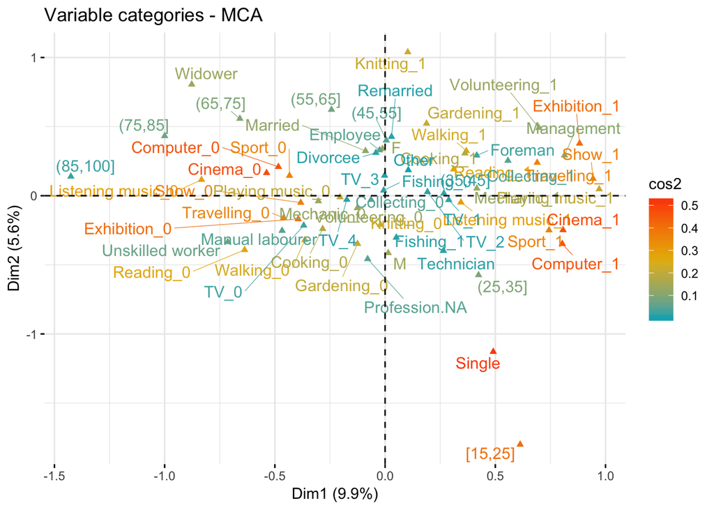

```r
#1b.
library(factoextra)
fviz_mca_var(res.MCA,
             col.var="cos2", repel=TRUE,
             gradient.cols = c("#00AFBB", "#E7B800", "#FC4E07"))
```

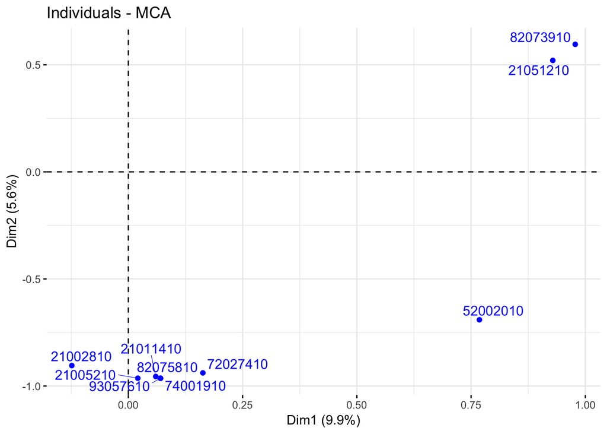

```r
#1c.
fviz_mca_ind(res.MCA, select.ind = list(cos2=10),
             col.var="cos2", repel=TRUE,
             gradient.cols = c("#00AFBB", "#E7B800", "#FC4E07"))
```

2. Effectuer la même analyse sur les variables 1 à 18 (de `reading` à `TV`, sans les variables socio-démographiques).
   1. Visualiser seulement les 10 variables avec les plus grands cosinus carrés
   2. Comment peut-on interpréter ce graphique ?

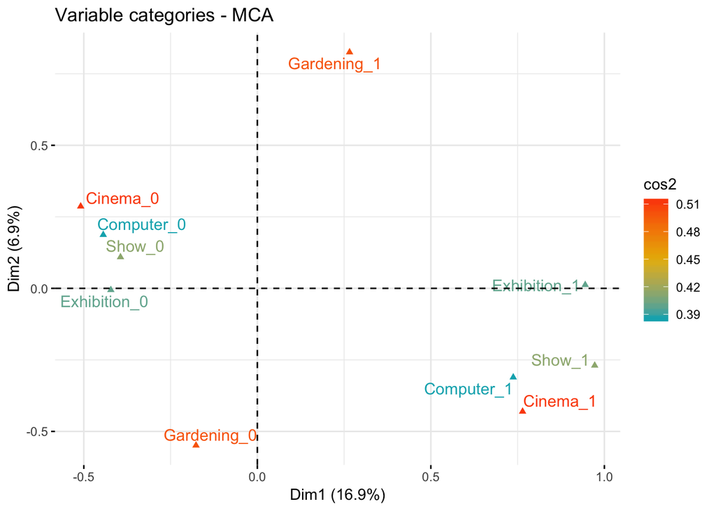

```r
#2.
res.MCA2 <- MCA(hobbies[,-c(19:23)], graph = FALSE)

#2a.
fviz_mca_var(res.MCA2,
             col.var="cos2", repel=TRUE, select.var = list(cos2=10),
             gradient.cols = c("#00AFBB", "#E7B800", "#FC4E07"))
```

```r
#2b.
#Groupement d'activités culturelles et ordinateur vs groupement sans ces activités
```

3. Effectuer la même analyse sur les variables 1 à 18 avec les variables 19 à 21 en variables illustratives.
   1. Visualiser seulement les 10 variables avec les plus grands cosinus carrés.
   2. Comment peut-on interpréter ce graphique ?

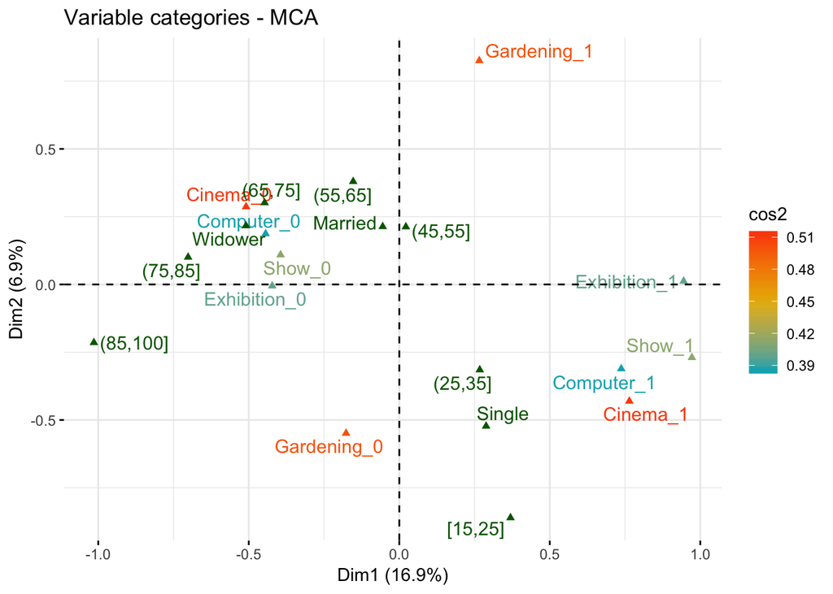

```r
#3.
res.MCA3 <- MCA(hobbies[,-c(22,23)], quali.sup = 19:21, graph = FALSE)

#3a
fviz_mca_var(res.MCA3,
             col.var="cos2", repel=TRUE, select.var = list(cos2=10),
             gradient.cols = c("#00AFBB", "#E7B800", "#FC4E07"))
```

```r
#3b. Groupement d'activités culturelles plus associé aux personnes célibataires et entre 26 et 35 ans,
#groupement non culturel plus associé aux personnes mariées, veuves et entre 66 et 85 ans
```